# Loan Data from Prosper

## by Abdelkarim Fathi

- Preliminary Wrangling
- Pre-Exploration step
- Univariate Exploration
- Bivariate Exploration
- Multivariate Exploration

## Preliminary Wrangling

> Through this notebook, I'll try to investigate a data set of Prosper loans of which around 113k rows and 81 related features in order to judge and get insights regarding their risk rating approach.

```python
# import all packages and set plots to be embedded inline
import numpy as np
import pandas as pd
import matplotlib.pyplot as plt
import matplotlib as mplt
import seaborn as sb

%matplotlib inline
pd.options.display.max_colwidth=1000
pd.options.display.max_rows=None
pd.options.display.max_columns=None
pd.options.display.precision=2
```

```python
#Loading the data set into data frame
df= pd.read_csv('prosperLoanData.csv')
```

```python
df.shape
```

```
(113937, 81)
```

```python
df.sample(2)
```

|  | ListingKey | ListingNumber | ListingCreationDate | CreditGrade | Term | LoanStatus | ClosedDate | BorrowerAPR | BorrowerRate | LenderYield | EstimatedEffectiveYield | EstimatedLoss | EstimatedReturn | ProsperRating (numeric) | ProsperRating (Alpha) | ProsperScore | ListingCategory (numeric) | BorrowerState | Occupation | EmploymentStatus | EmploymentStatusDuration | IsBorrowerHomeowner | CurrentlyInGroup | GroupKey | DateCreditPulled | CreditScoreRangeLower | CreditScoreRangeUpper | FirstRecordedCreditLine | CurrentCreditLines | … |
| --- | --- | --- | --- | --- | --- | --- | --- | --- | --- | --- | --- | --- | --- | --- | --- | --- | --- | --- | --- | --- | --- | --- | --- | --- | --- | --- | --- | --- | --- | --- |
| 17917 | 9A19359498369703045811A | 1000921 | 2013-11-17 10:09:05.483000000 | NaN | 36 | Current | NaN | 0.23 | 0.19 | 0.18 | 0.17 | 0.08 | 0.09 | 4.0 | C | 2.0 | 1 | TX | Truck Driver | Employed | 69.0 | True | False | NaN | 2013-11-17 10:09:07 | 720.0 | 739.0 | 1993-03-12 00:00:00 | 11.0 | … |
| 65633 | 4F0C359985826233120BEA0 | 1113475 | 2014-01-16 07:31:21.427000000 | NaN | 60 | Current | NaN | 0.16 | 0.14 | 0.13 | 0.12 | 0.05 | 0.07 | 5.0 | B | 8.0 | 7 | CT | Professional | Employed | 151.0 | True | False | NaN | 2014-01-16 07:31:21 | 660.0 | 679.0 | 2001-03-20 00:00:00 | 8.0 | … |

### What is the structure of your dataset?

> Its consisting of 113,937 values and 81 features. Some of them are loan features and in the type of categorical data (e.g. LoanStatus, IncomeRange, and Term) and others in form of quantitative data type (e.g. LoanOriginalAmount, and BorrowerRate)

### What is/are the main feature(s) of interest in your dataset?

> My analysis will target `Prospers Risk Rating Approach`. I'll try to find out if this approach is efficient enough to detect and eliminate risks through the system and save investor money or it has some weak points. So, I'll consider classifying my interest features into two main groups:
> - $First$ one will be related to the loan itself, which is related to the investor as well, at which three of them are Categorical type (`ProsperRiskRating`, `Term`, and `LoanStatus`) and three are continuous quantitative type(`BorrowerRate`, `LoanOriginalAmount`, and `MonthlyLoanPayment`).
> - $Second$ one will be related to Borrower with the same schema of the first group, three categorical features (`BorrowerState`, `EmploymentStatus`, and `IncomeRange`) and three continuous quantitative (`DebtToIncomeRatio`, `ProsperPrincipalBorrowed`, and `ProsperPrincipalOutstanding`).

### What features in the dataset do you think will help support your investigation into your feature(s) of interest?

> Am sure that (`LoanStatus`) will be very important to spot if ,initially,(`ProsperRiskRating`) was accurate or not. Also, if (`IncomeRange`) was a tempting factor for better risk evaluation or not. Plus, do (`BorrowerState`, `EmploymentStatus`, and `DebtToIncomeRatio`) involved in the process or not. Moreover, what could be the relation between (`Term`, `ProsperRiskRating`, and `BorrowerRate/LoanOriginalAmount`).

##### - Investor (loan) features:

> - ProsperRiskRating ($AA_{Lowest} - A - B - C - D - E - HR_{Highest}$)
> - LoanStatus
> - Term
> - BorrowerRate
> - LoanOriginalAmount
> - MonthlyLoanPayment

##### - Borrower (consumer) features:

> - BorrowerState
> - EmploymentStatus
> - IncomeRange
> - DebtToIncomeRatio
> - ProsperPrincipalBorrowed (Total principal borrowed on Prosper loans at that time. If null,no prior loans.)
> - ProsperPrincipalOutstanding (Principal outstanding on Prosper loans at that time. If null,no prior loans.)

## Pre-Exploration step:

> Here I'll extract before mentioned features and look for / clean any Tidiness / Quality issues.

```python
#Select specific columns to study
selected_cols=['CreditGrade','ProsperRating (Alpha)','Term','LoanStatus','BorrowerRate','BorrowerState',
               'EmploymentStatus','DebtToIncomeRatio','IncomeRange','ProsperPrincipalBorrowed',
               'ProsperPrincipalOutstanding','LoanOriginalAmount','MonthlyLoanPayment']
df2= df.loc[:, selected_cols]
```

```python
# Rename this column "ProsperRating (Alpha)" to "ProsperRatingAlpha" to be more consistent and easily in coding.
df2.rename(columns={'ProsperRating (Alpha)':'ProsperRatingAlpha'}, inplace=True)
```

```python
# Columns "CreditGrade" and "ProsperRating (Alpha)" representing "Loan's Risk Rating" but each one for specific period of time.
# So, I'll combine them into one column "ProsperRiskRating" and drop the original two columns

df2['CreditGrade'].fillna("", inplace= True)
df2['ProsperRatingAlpha'].fillna("", inplace= True)

df2['ProsperRiskRating']= df2[['CreditGrade','ProsperRatingAlpha']].agg("".join, axis=1)
df2.drop(['CreditGrade', 'ProsperRatingAlpha'], axis=1, inplace=True)
```

```python
# Rearrange data frame columns in specific shape
df2= df2.iloc[:, [11,1,0,2,9,10,3,4,6,5,7,8]]
```

```python
# Drop Null values in "BorrowerState", "EmploymentStatus", and "DebtToIncomeRatio" only
df2.dropna(subset=['BorrowerState','EmploymentStatus','DebtToIncomeRatio'], inplace=True)
```

```python
# Drop empty/null rows in "ProsperRiskRating" column
df2.drop(df2[df2['ProsperRiskRating'] == ""].index, inplace=True)
```

```python
# Fill all Null value in "ProsperPrincipalBorrowed" with '0', as here null means that borrower has no historical loans
df2.ProsperPrincipalBorrowed.fillna(0, inplace=True)
```

```python
# Fill all Null value in "ProsperPrincipalOutstanding" with '0', as here null means that borrower has no outstanding balance
df2.ProsperPrincipalOutstanding.fillna(0, inplace=True)
```

```python
# Multiply all "BorrowerRate" values by 100 to easily interpreting in visualization
df2['BorrowerRate']= df2['BorrowerRate']*100
```

```python
# Values in "DebtToIncomeRatio" are inconsistent, some in fracture format and others not. So, will multiply values <= 1 by 100
df2['DebtToIncomeRatio']= df2['DebtToIncomeRatio'].apply(lambda x: x*100 if x <= 1 else x)
```

```python
df2.info()
```

```
<class 'pandas.core.frame.DataFrame'>
Int64Index: 98965 entries, 0 to 113936
Data columns (total 12 columns):
 #   Column                       Non-Null Count  Dtype
---  ------                       --------------  -----
 0   ProsperRiskRating            98965 non-null  object
 1   LoanStatus                   98965 non-null  object
 2   Term                         98965 non-null  int64
 3   BorrowerRate                 98965 non-null  float64
 4   LoanOriginalAmount           98965 non-null  int64
 5   MonthlyLoanPayment           98965 non-null  float64
 6   BorrowerState                98965 non-null  object
 7   EmploymentStatus             98965 non-null  object
 8   IncomeRange                  98965 non-null  object
 9   DebtToIncomeRatio            98965 non-null  float64
 10  ProsperPrincipalBorrowed     98965 non-null  float64
 11  ProsperPrincipalOutstanding  98965 non-null  float64
dtypes: float64(5), int64(2), object(5)
memory usage: 9.8+ MB
```

```python
df2.sample(2)
```

|  | ProsperRiskRating | LoanStatus | Term | BorrowerRate | LoanOriginalAmount | MonthlyLoanPayment | BorrowerState | EmploymentStatus | IncomeRange | DebtToIncomeRatio | ProsperPrincipalBorrowed | ProsperPrincipalOutstanding |
| --- | --- | --- | --- | --- | --- | --- | --- | --- | --- | --- | --- | --- |
| 88543 | B | Completed | 36 | 16.56 | 7000 | 248.04 | MI | Full-time | $25,000-49,999 | 31.0 | 10020.0 | 1978.83 |
| 107515 | C | Defaulted | 36 | 17.00 | 1000 | 35.65 | WI | Full-time | $50,000-74,999 | 13.0 | 0.0 | 0.00 |

## Univariate Exploration

> Here, I'll plot each feature to gain more insights about each one individually.

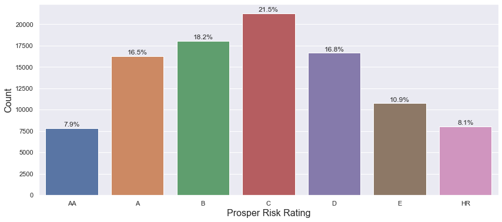

```python
# ProsperRiskRating ( 𝐴𝐴_(l𝑜𝑤𝑒𝑠𝑡)−𝐴−𝐵−𝐶−𝐷−𝐸−𝐻𝑅_(h𝑖𝑔ℎ𝑒𝑠𝑡 )
sb.set(rc={'figure.figsize':(14,6)})
sb.set_style('darkgrid')

bin_order=['AA','A','B','C','D','E','HR']
sb.countplot(data=df2, x = 'ProsperRiskRating', order= bin_order)

counts= df2['ProsperRiskRating'].value_counts()[bin_order]
prop= ['{:0.1f}%'.format((i / df2.shape[0])*100) for i in counts]
for i in range(len(prop)):
    plt.text(i, counts[i]+200, prop[i], ha='center')

plt.xlabel('Prosper Risk Rating', fontsize=16)
plt.ylabel('Count', fontsize=16);
```

> Almost 50% of cases are in the middle zone, about one-fifth of the listed loan cases labeled as "`C`" or moderate level of risk following by the "`B`" and "`D`" class. While roughly 8% of cases considered as very low of risk "`AA`" and that is almost equal to the higher level of risk "`HR`".

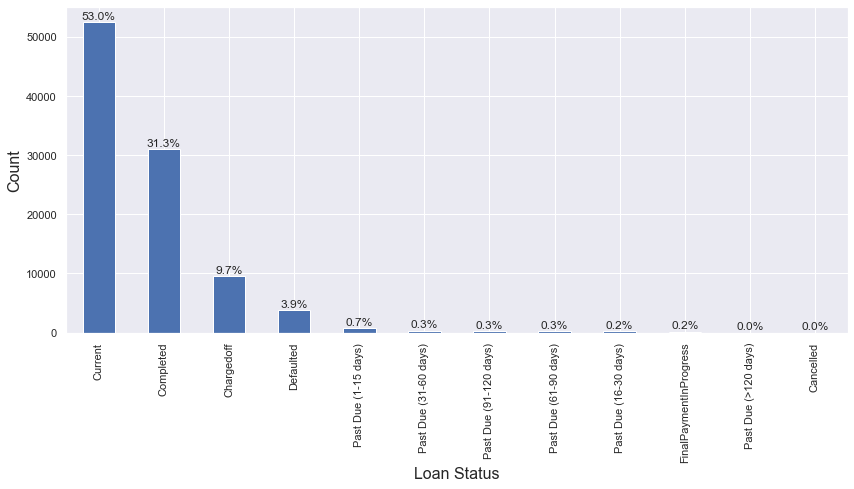

```python
sb.set(rc={'figure.figsize':(14,6)})
sb.set_style('darkgrid')

counts= df2['LoanStatus'].value_counts()
prop= ['{:0.1f}%'.format((i / df2.shape[0])*100) for i in counts]
counts.plot(kind='bar')
for i in range(len(prop)):
    plt.text(i, counts[i]+500, prop[i], ha='center')

plt.xlabel('Loan Status', fontsize=16)
plt.ylabel('Count', fontsize=16);
```

> If we consider the `Current` and `Completed` groups together as a successful cases, it'll be more than 84% of cases are succeeded cases and related borrowers showing very positive commitment. At the same time, regarding `Chargedoff` and `Defaulted` status, there is a considerable percentage of cases are struggling, almost 13.6%, and their investors declared that they can't collect their investments' installments.

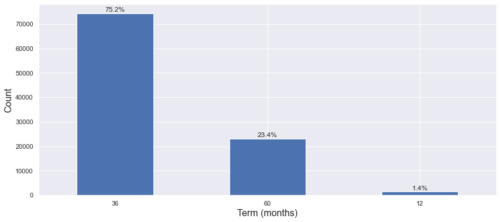

```python
sb.set(rc={'figure.figsize':(14,6)})
sb.set_style('darkgrid')

counts= df2['Term'].value_counts()
prop= ['{:0.1f}%'.format((i / df2.shape[0])*100) for i in counts]
counts.plot(kind='bar', rot=0)
for i in range(len(prop)):
    plt.text(i, counts[counts.index[i]]+700, prop[i], ha='center')

plt.xlabel('Term (months)', fontsize=16)
plt.ylabel('Count', fontsize=16);
```

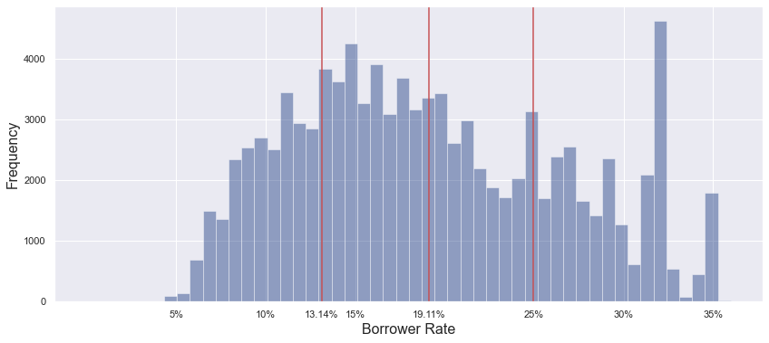

```python
sb.set(rc={'figure.figsize':(14,6)})
sb.set_style('darkgrid')

sb.distplot(df2['BorrowerRate'],hist=True, kde=False, color='#062777')
plt.axvline(df2['BorrowerRate'].mean(), color='r')
plt.axvline(df2['BorrowerRate'].describe()[4], color='r')
plt.axvline(df2['BorrowerRate'].describe()[6], color='r')

plt.xticks(ticks=[5,10,df2['BorrowerRate'].describe()[4],15,df2['BorrowerRate'].mean(),df2['BorrowerRate'].describe()[6],30,35],
           labels=['5%','10%','13.14%','15%','19.11%','25%','30%','35%'],rotation=0)

plt.xlabel('Borrower Rate', fontsize=16)
plt.ylabel('Frequency', fontsize=16);
```

> `Borrower Rate` shows multimodal distribution with many peaks specially the biggest one between 30% and 35%. However, 50% of rates lay between 13.14% and 25% (Inter-Quartile) with a mean value of 19.11%.

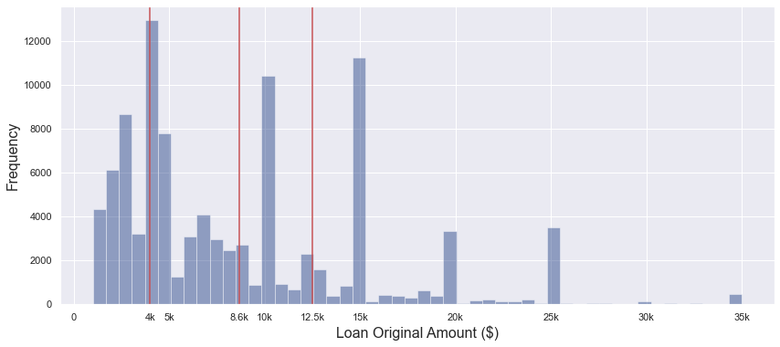

```python
sb.set(rc={'figure.figsize':(14,6)})
sb.set_style('darkgrid')

sb.distplot(df2['LoanOriginalAmount'],hist=True, kde=False, color='#062777')
plt.axvline(df2['LoanOriginalAmount'].describe()[4], color='r')
plt.axvline(df2['LoanOriginalAmount'].mean(), color='r')
plt.axvline(df2['LoanOriginalAmount'].describe()[6], color='r')

plt.xticks(ticks=[0,df2['LoanOriginalAmount'].describe()[4],5000,df2['LoanOriginalAmount'].mean(),10000,df2['LoanOriginalAmount'].describe()[6],15000,20000,25000,30000,35000],
           labels=['0','4k','5k','8.6k','10k','12.5k','15k','20k','25k','30k','35k'],rotation=0)

plt.xlabel('Loan Original Amount ($)', fontsize=16)
plt.ylabel('Frequency', fontsize=16);
```

> `LoanOriginalAmount` shows multimodal with many big spikes. But, 50% of amounts lay between `$4,000` (the most common amount as well) and `$12,500` with a mean value of `$8,600`.

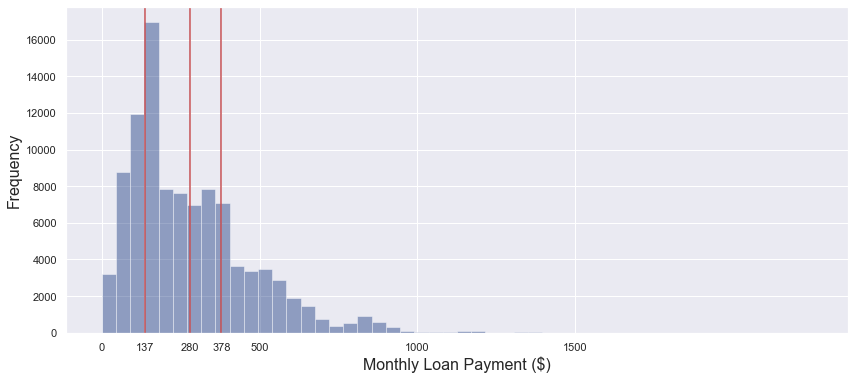

```python
sb.set(rc={'figure.figsize':(14,6)})
sb.set_style('darkgrid')

sb.distplot(df2['MonthlyLoanPayment'],hist=True, kde=False, color='#062777')
plt.axvline(df2['MonthlyLoanPayment'].describe()[4], color='r')
plt.axvline(df2['MonthlyLoanPayment'].mean(), color='r')
plt.axvline(df2['MonthlyLoanPayment'].describe()[6], color='r')

plt.xticks(ticks=[0,df2['MonthlyLoanPayment'].describe()[4],df2['MonthlyLoanPayment'].mean(),df2['MonthlyLoanPayment'].describe()[6],500,1000,1500],
           labels=['0','137','280','378','500','1000','1500'],rotation=0)

plt.xlabel('Monthly Loan Payment ($)', fontsize=16)
plt.ylabel('Frequency', fontsize=16);
```

> `MonthlyLoanPayment` tends to be a more right-skewed distribution with a big spike at `$137` (first quartile). Its inter quartile is between 137 and 378 and mean of 280.

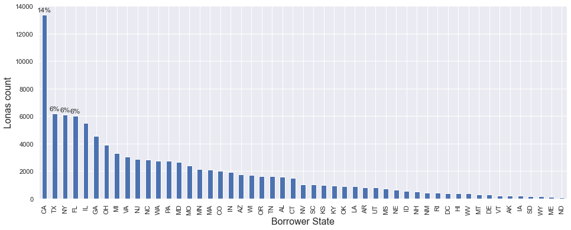

```python
sb.set(rc={'figure.figsize':(16,6)})
sb.set_style('darkgrid')

df2['BorrowerState'].value_counts().plot(kind='bar')
counts= df2['BorrowerState'].value_counts()
prop= ['{:0.0f}%'.format((i / df2.shape[0])*100) for i in counts]
for i in range(4):
    plt.text(i, counts[counts.index[i]]+200, prop[i], ha='center')

plt.xlabel('Borrower State', fontsize=16)
plt.ylabel('Lonas count', fontsize=16);
```

> More than 13% of loans go for borrowers from California followed by Texas, New York, and Florida with the same percentage of 6%, while North-Dakota has the lowest value.

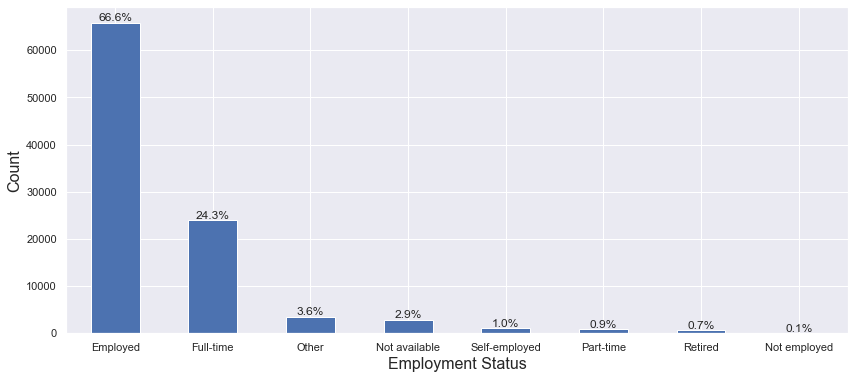

```python
sb.set(rc={'figure.figsize':(14,6)})
sb.set_style('darkgrid')

counts= df2['EmploymentStatus'].value_counts()
prop= ['{:0.1f}%'.format((i / df2.shape[0])*100) for i in counts]
counts.plot(kind='bar', rot=0)
for i in range(len(prop)):
    plt.text(i, counts[i]+300, prop[i], ha='center')

plt.xlabel('Employment Status', fontsize=16)
plt.ylabel('Count', fontsize=16);
```

> The vast majority of borrowers are classified either as `Employed` or `Full-Time`.

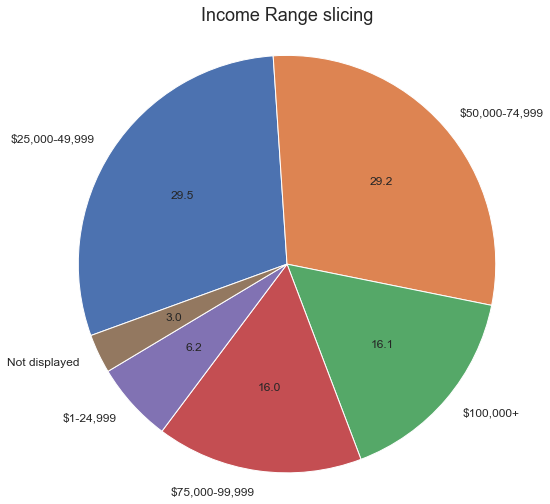

```python
sb.set(rc={'figure.figsize':(16,6)})
sb.set_style('darkgrid')

df2.IncomeRange.value_counts()[:-1].plot(kind='pie', radius=1.6, autopct='%.1f', fontsize=12, startangle=200,counterclock=False)

plt.title('Income Range slicing', pad=80, fontsize=18);
```

> Middle income borrowers seized almost 60% of loans then comes the higher income category with about 32%.

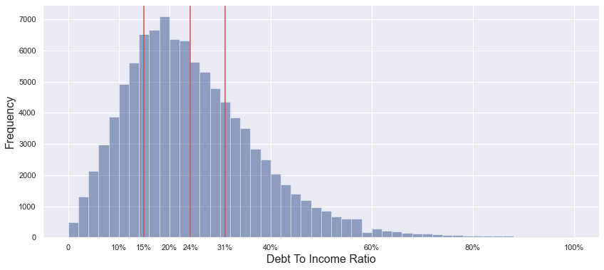

```python
sb.set(rc={'figure.figsize':(14,6)})
sb.set_style('darkgrid')

sb.distplot(df2['DebtToIncomeRatio'],hist=True, kde=False, color='#062777')
plt.axvline(df2['DebtToIncomeRatio'].describe()[4], color='r')
plt.axvline(df2['DebtToIncomeRatio'].mean(), color='r')
plt.axvline(df2['DebtToIncomeRatio'].describe()[6], color='r')

plt.xticks(ticks=[0,10,df2['DebtToIncomeRatio'].describe()[4],20,df2['DebtToIncomeRatio'].mean(),df2['DebtToIncomeRatio'].describe()[6],40,60,80,100],
           labels=['0','10%','15%','20%','24%','31%','40%','60%','80%','100%'],rotation=0)

plt.xlabel('Debt To Income Ratio', fontsize=16)
plt.ylabel('Frequency', fontsize=16);
```

> `DebtToIncomeRatio` skewed distributionally to the right; 50% of values are between 15% and 31% and mean at 24%.

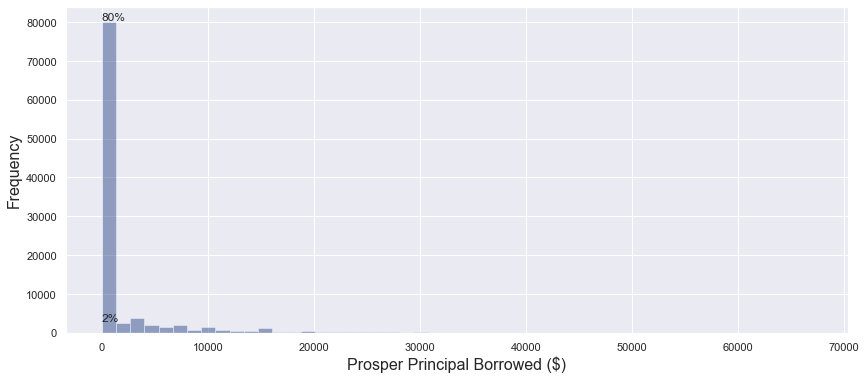

```python
# ProsperPrincipalBorrowed (Total principal borrowed on Prosper loans at that time. If null,no prior loans.)
sb.set(rc={'figure.figsize':(14,6)})
sb.set_style('darkgrid')

sb.distplot(df2['ProsperPrincipalBorrowed'],hist=True, kde=False, color='#062777')
counts= df2['ProsperPrincipalBorrowed'].value_counts()
prop= ['{:0.0f}%'.format((i / df2.shape[0])*100) for i in counts]
for i in range(2):
    plt.text(i, counts[counts.index[i]]+2000, prop[i], va='center')

plt.xlabel('Prosper Principal Borrowed ($)', fontsize=16)
plt.ylabel('Frequency', fontsize=16);
```

> No identified distribution, instead `80%` of borrowers just made their first prosper loan.

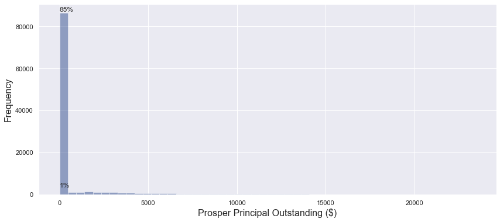

```python
# ProsperPrincipalOutstanding (Principal outstanding on Prosper loans at that time. If null,no prior loans.)
sb.set(rc={'figure.figsize':(14,6)})
sb.set_style('darkgrid')

sb.distplot(df2['ProsperPrincipalOutstanding'],hist=True, kde=False, color='#062777')
counts= df2['ProsperPrincipalOutstanding'].value_counts()
prop= ['{:0.0f}%'.format((i / df2.shape[0])*100) for i in counts]
for i in range(2):
    plt.text(i, counts[counts.index[i]]+3500, prop[i], va='center')

plt.xlabel('Prosper Principal Outstanding ($)', fontsize=16)
plt.ylabel('Frequency', fontsize=16);
```

> Percentage increased to `85%` which means that only `5%` of recently prosper borrowers committed to their loans.

### Discuss the distribution(s) of your variable(s) of interest. Were there any unusual points? Did you need to perform any transformations?

> Regarding `Prosper Principal Borrowed` and `Prosper Principal Outstanding`, there is no identified distribution, but no need to transform them. Instead `Debt To Income Ratio` has the better distribution even it's skewed to the right.

### Of the features you investigated, were there any unusual distributions? Did you perform any operations on the data to tidy, adjust, or change the form of the data? If so, why did you do this?

> `Prosper Principal Borrowed` and `Prosper Principal Outstanding`distributions shows huge spike in one value "0", however, its still presenting useful isght reagrding its data.

> I filtered out the columns of features of interest then made the following changes:
> - Rename this column "ProsperRating (Alpha)" to "ProsperRatingAlpha" to be more consistent and easily in coding.
> - Columns "CreditGrade" and "ProsperRating (Alpha)" representing "Loan Risk Rating" but each one for a specific period of time. So, I combined them into one column "ProsperRiskRating" and drop the original two columns.
> - Rearrange data frame columns in a specific shape to set each feature in alignment with its group of features (Investor, Borrower)
> - Drop Null values in "BorrowerState", "employment status", and "DebtToIncomeRatio" only to avoid these missing data affect in my analysis.
> - Drop null rows in the "ProsperRiskRating" column to not conflict with my categorical based analysis.
> - Fill all Null value in "ProsperPrincipalBorrowed" with '0', as here null means that borrower has no historical loans
> - Fill all Null value in "ProsperPrincipalOutstanding" with '0', as here null means that borrower has no outstanding balance
> - Values in "DebtToIncomeRatio" are inconsistent, some in fracture format and others not. So, will multiply values <= 1 by 100
> - Multiply all "BorrowerRate" values by 100 to easily interpreting in visualization

## Bivariate Exploration

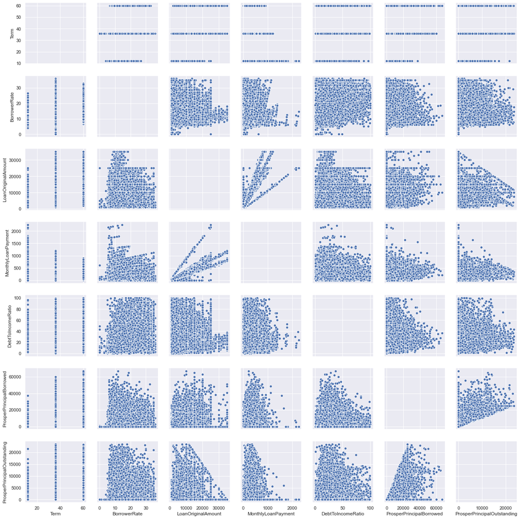

```python
sb.set(rc={'figure.figsize':(40,20)})
sb.set_style('darkgrid')

g = sb.PairGrid(df2)
g.map_offdiag(sb.scatterplot);
```

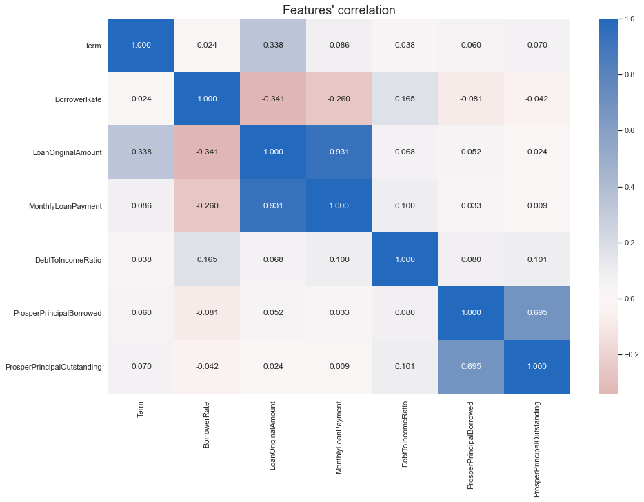

```python
# Checking the correlation factor for the visualized features
sb.set(rc={'figure.figsize':(15,10)})
sb.set_style('darkgrid')

sb.heatmap(df2.corr(), annot = True, fmt = '.3f', cmap = 'vlag_r', center = 0)
plt.title('Features\' correlation', fontsize=18);
```

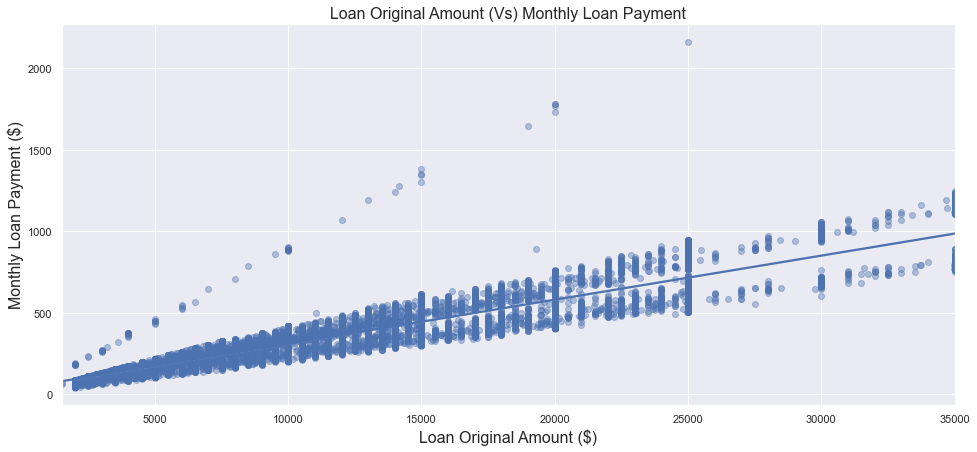

```python
# Considering only Running loan not stopped ones regardless of the stopping reasons
sb.set(rc={'figure.figsize':(16,7)})
sb.set_style('darkgrid')

tmp= df2.query('MonthlyLoanPayment != 0 & LoanStatus != ["Completed","Defaulted","Chargedoff","Cancelled"]')
sb.regplot(x="LoanOriginalAmount", y="MonthlyLoanPayment", data=tmp, scatter_kws={'alpha':0.4})

plt.title('Loan Original Amount (Vs) Monthly Loan Payment', fontsize=16)
plt.xlabel('Loan Original Amount ($)', fontsize=16)
plt.ylabel('Monthly Loan Payment ($)', fontsize=16);
```

> There is a consistent and very positive correlation between `Loan Original Amount` and `Monthly Loan Payment`. It's common sense and economical wise that as loan amount increase monthly payment increase.

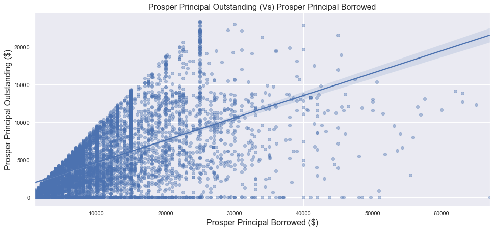

```python
# Considering only Running loan not stopped ones regardless of the stopping reasons
sb.set(rc={'figure.figsize':(16,7)})
sb.set_style('darkgrid')

tmp= df2.query('ProsperPrincipalOutstanding !=0 & ProsperPrincipalBorrowed !=0 & LoanStatus != ["Completed","Defaulted","Chargedoff","Cancelled"]')
sb.regplot(y="ProsperPrincipalOutstanding", x="ProsperPrincipalBorrowed", data=tmp, scatter_kws={'alpha':0.4})

plt.title('Prosper Principal Outstanding (Vs) Prosper Principal Borrowed', fontsize=16)
plt.ylabel('Prosper Principal Outstanding ($)', fontsize=16)
plt.xlabel('Prosper Principal Borrowed ($)', fontsize=16);
```

> Maybe the regression fitting line appears positively from the regression perspective, but I think 'P-Value" and "adj R^2" won't be strong enough. It's noticeable that as the total borrowed amount increases, the probability of outstanding amount increases and reaches its highest peak at the value between 20k and 30k.

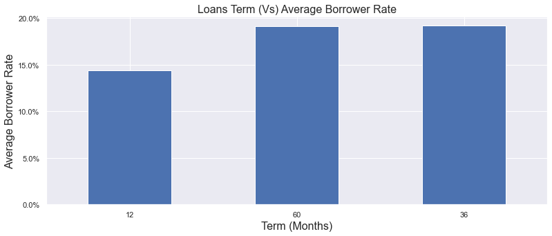

```python
sb.set(rc={'figure.figsize':(13,5)})
sb.set_style('darkgrid')

ax= df2.groupby('Term')['BorrowerRate'].mean().sort_values(ascending=True).plot(kind='bar', rot=0)

plt.title('Loans Term (Vs) Average Borrower Rate', fontsize=16)
plt.xlabel('Term (Months)', fontsize=16)
plt.ylabel('Average Borrower Rate', fontsize=16)
plt.yticks(ticks=np.arange(0,25,5))
ax.yaxis.set_major_formatter(mplt.ticker.PercentFormatter());
```

> On-average the borrower rate for the loan term of 36 months and 60 months are equal that equal almost 19% on average.

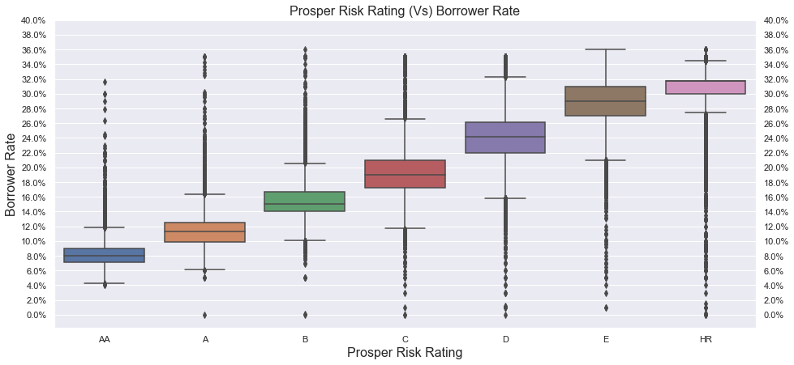

```python
#
sb.set(rc={'figure.figsize':(15.5,7)})
sb.set_style('darkgrid')

box_order= ['AA','A','B','C','D','E','HR']
ax= sb.boxplot(x='ProsperRiskRating', y='BorrowerRate', data= df2, order= box_order)

plt.title('Prosper Risk Rating (Vs) Borrower Rate', fontsize=16)
plt.xlabel('Prosper Risk Rating', fontsize=16)
plt.ylabel('Borrower Rate', fontsize=16)
plt.yticks(ticks=np.arange(0,42,2))
ax.tick_params(labelright=True)
ax.yaxis.set_major_formatter(mplt.ticker.PercentFormatter());
```

> Lowest risk `AA` rate values bounded between almost 7% - 9% and around mean of 8% with medium dispersed upward tail. While in the `HR` cases are totally settled between 30%-32% with long and bold tail downward. They are motivating lower risk borrowers to involve more with a very competitive borrowing rate.

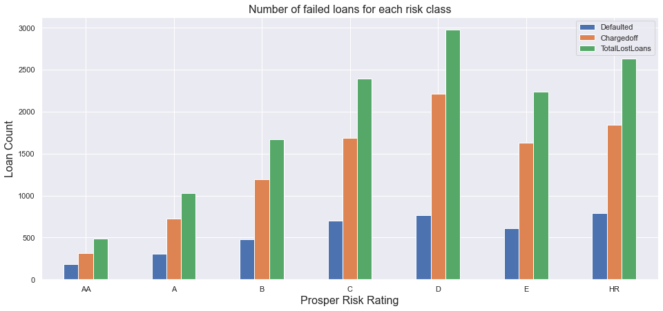

```python
# Considering Defaulted and Chargedoff lonas as stopped/failed loans
sb.set(rc={'figure.figsize':(16,7)})
sb.set_style('darkgrid')

tmp= df2.query('LoanStatus == ["Defaulted","Chargedoff"]').groupby(['ProsperRiskRating','LoanStatus'])['Term'].count().reset_index()
tmp1= tmp.query('LoanStatus == "Chargedoff"').rename(columns={'Term':'Chargedoff'})
tmp1.drop('LoanStatus', axis=1, inplace=True)
tmp2= tmp.query('LoanStatus == "Defaulted"').rename(columns={'Term':'Defaulted'})
tmp2.drop('LoanStatus', axis=1, inplace=True)
tmp= pd.merge(tmp1, tmp2, left_on= 'ProsperRiskRating', right_on= 'ProsperRiskRating', how= 'inner').set_index('ProsperRiskRating').loc[['AA','A','B','C','D','E','HR'],:]
tmp['TotalLostLoans']= tmp['Chargedoff'] + tmp['Defaulted']
tmp= tmp.loc[:,['Defaulted','Chargedoff','TotalLostLoans']]

tmp.plot(kind='bar', width=.5, rot=0)

plt.legend()
plt.title('Number of failed loans for each risk class', fontsize=16)
plt.xlabel('Prosper Risk Rating', fontsize=16)
plt.ylabel('Loan Count', fontsize=16);
```

> Most of the non-committed cases related to the `D` risk class with the highest count of `Chargedoff` loans followed by the `HR` and `C` classes; it seems that many cases classified incorrectly. On the other hand, class `AA` showing the highest commitment amongst all other classes and with a considerable gap over the next risk level `A`.

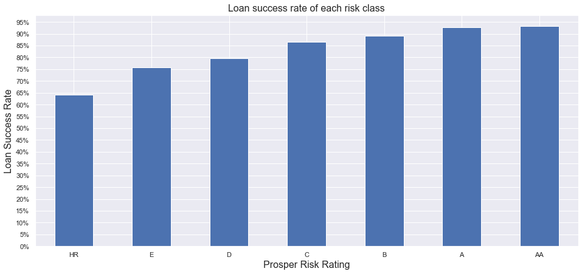

```python
#
sb.set(rc={'figure.figsize':(16,7)})
sb.set_style('darkgrid')

tmp1= df2.groupby(['ProsperRiskRating', 'LoanStatus'])['Term'].count().reset_index().query('LoanStatus == "Completed"').loc[:,['ProsperRiskRating','Term']].rename(columns={'Term':'CompletedLoans'})
tmp2= df2.groupby(['ProsperRiskRating', 'LoanStatus'])['Term'].count().reset_index().query('LoanStatus == "Current"').loc[:,['ProsperRiskRating','Term']].rename(columns={'Term':'CurrentLoans'})
tmp3= df2.groupby(['ProsperRiskRating'])['Term'].count().reset_index().loc[:,['ProsperRiskRating','Term']].rename(columns={'Term':'TotalLoans'})
tmp= pd.merge(tmp1, tmp2, on= 'ProsperRiskRating', how= 'inner').merge(tmp3, on= 'ProsperRiskRating', how= 'inner').set_index('ProsperRiskRating')
tmp['SuccessRate']= ( tmp['CompletedLoans'] + tmp['CurrentLoans'] )/ tmp['TotalLoans']*100


ax= tmp['SuccessRate'].sort_values(ascending=True).plot(kind='bar', width=.5, rot=0)

plt.title('Loan success rate of each risk class', fontsize=16)
plt.xlabel('Prosper Risk Rating', fontsize=16)
plt.ylabel('Loan Success Rate', fontsize=16)
plt.yticks(ticks=np.arange(0,100,5))
ax.yaxis.set_major_formatter(mplt.ticker.PercentFormatter());
```

> The lowest risk class `AA` has the higher success rate 93%, and the oppostite for the highest risk class `HR` has the lowest rate 65%.

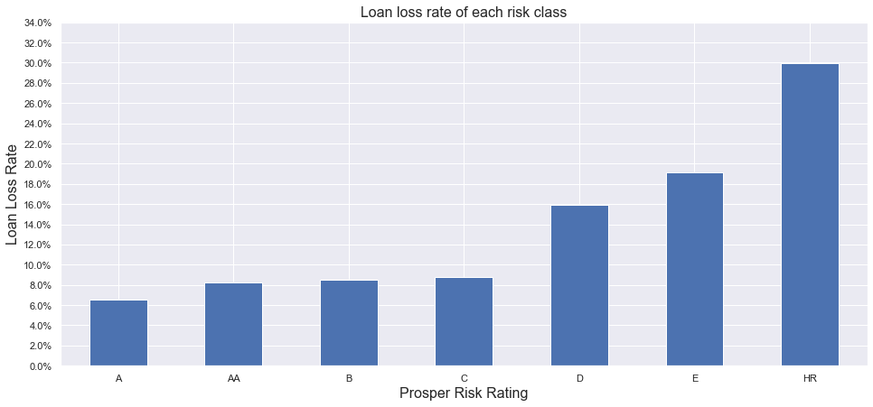

```python
sb.set(rc={'figure.figsize':(16,7)})
sb.set_style('darkgrid')

tmp= df2.query('LoanStatus == ["Defaulted","Chargedoff"]').groupby('ProsperRiskRating')['LoanOriginalAmount'].sum().reset_index()
tmp.rename(columns={'LoanOriginalAmount':'LoansLost'}, inplace=True)
tmp['TotalLoans']= df2.groupby('ProsperRiskRating')['LoanOriginalAmount'].sum().reset_index()['LoanOriginalAmount']
tmp['LossRate']= tmp['LoansLost'] / tmp['TotalLoans']*100
tmp= tmp.set_index('ProsperRiskRating')

ax= tmp['LossRate'][0:7].sort_values(ascending=True).plot(kind='bar', width=.5, rot=0)

plt.title('Loan loss rate of each risk class', fontsize=16)
plt.xlabel('Prosper Risk Rating', fontsize=16)
plt.ylabel('Loan Loss Rate', fontsize=16)
plt.yticks(ticks=np.arange(0,35,2))
ax.yaxis.set_major_formatter(mplt.ticker.PercentFormatter());
```

> Class `A` has loss rate less than class `AA` that almost equal to class `B`, while class `HR` has the far highest rate 30%.

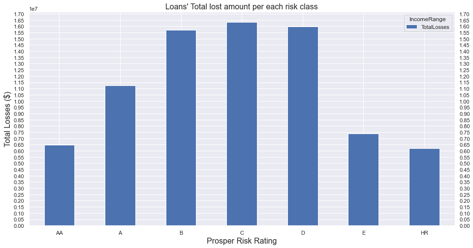

```python
#
sb.set(rc={'figure.figsize':(15.5,8)})
sb.set_style('darkgrid')

tmp= df2.query('LoanStatus == ["Defaulted","Chargedoff"]').loc[:,['ProsperRiskRating','IncomeRange','LoanOriginalAmount']].groupby(['ProsperRiskRating','IncomeRange'])['LoanOriginalAmount'].sum().to_frame().reset_index()#.set_index('ProsperRiskRating')
tmp.rename(columns={'LoanOriginalAmount':'TotalLostLoans'}, inplace=True)
tmp= tmp.pivot(index= 'ProsperRiskRating', columns= 'IncomeRange', values= 'TotalLostLoans')
tmp['TotalLosses']= tmp['$1-24,999']+tmp['$25,000-49,999']+tmp['$50,000-74,999']+tmp['$75,000-99,999']+tmp['$100,000+']
tmp= tmp.loc[['AA','A','B','C','D','E','HR'],['TotalLosses']]

ax= tmp.plot(kind='bar', rot=0)

plt.title('Loans\' Total lost amount per each risk class', fontsize=16)
plt.xlabel('Prosper Risk Rating', fontsize=16)
plt.ylabel('Total Losses ($)', fontsize=16)
ax.tick_params(labelright=True)
plt.yticks(ticks=np.arange(0,17500000,500000));
```

> Interestingly, while class `HR` has the highest loss rate; almost three times class `C`, but total amount lost in class `C` almost three times the amount of class `HR`, kind of `Simpsons-Paradox` !!.

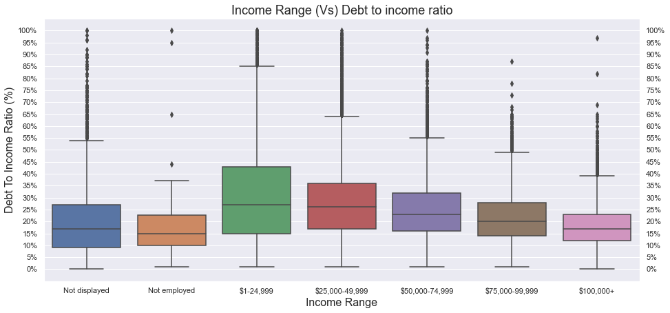

```python
#
sb.set(rc={'figure.figsize':(15.5,7)})
sb.set_style('darkgrid')

box_order= ['Not displayed','Not employed','$1-24,999','$25,000-49,999','$50,000-74,999','$75,000-99,999','$100,000+']
ax= sb.boxplot(x='IncomeRange', y='DebtToIncomeRatio', data= df2, order= box_order)

plt.title('Income Range (Vs) Debt to income ratio', fontsize=18)
plt.xlabel('Income Range', fontsize=16)
plt.ylabel('Debt To Income Ratio (%)', fontsize=16)
plt.yticks(ticks=np.arange(0,105,5))
ax.tick_params(labelright=True)
ax.yaxis.set_major_formatter(mplt.ticker.PercentFormatter());
```

> Low-income range `$1-24,999` has the highest ratio that reaches almost 44%. Meanwhile, the higher-income range `$100,000+`reaches only 24%, almost half of the low-income class.

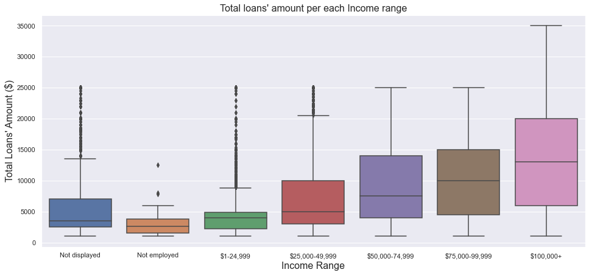

```python
#
sb.set(rc={'figure.figsize':(16,7)})
sb.set_style('darkgrid')

box_order= ['Not displayed','Not employed','$1-24,999','$25,000-49,999','$50,000-74,999','$75,000-99,999','$100,000+']
ax= sb.boxplot(x='IncomeRange', y='LoanOriginalAmount', data= df2, order= box_order)

plt.title('Total loans\' amount per each Income range', fontsize=16)
plt.xlabel('Income Range', fontsize=16)
plt.ylabel('Total Loans\' Amount ($)', fontsize=16);
```

> As the income range increase, total loans amount for each range increase which is alligned with the `Debt To Income Ratio` of each range.

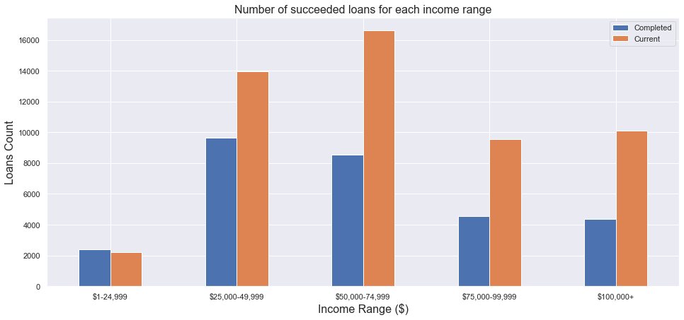

```python
# Considering only Completed and Current lonas as succeeded loans
sb.set(rc={'figure.figsize':(16,7)})
sb.set_style('darkgrid')

tmp= df2.query('LoanStatus == ["Completed","Current"]').groupby(['IncomeRange','LoanStatus'])['Term'].count().reset_index()
tmp1= tmp.query('LoanStatus == "Completed"').rename(columns={'Term':'Completed'})
tmp1.drop('LoanStatus', axis=1, inplace=True)
tmp2= tmp.query('LoanStatus == "Current"').rename(columns={'Term':'Current'})
tmp2.drop('LoanStatus', axis=1, inplace=True)
tmp= pd.merge(tmp1, tmp2, left_on= 'IncomeRange', right_on= 'IncomeRange', how= 'inner').set_index('IncomeRange')
tmp= tmp.loc[['$1-24,999','$25,000-49,999','$50,000-74,999','$75,000-99,999','$100,000+'],['Completed','Current']]

tmp.plot(kind='bar', width=.5, rot=0)

plt.title('Number of succeeded loans for each income range', fontsize=16)
plt.xlabel('Income Range ($)', fontsize=16)
plt.ylabel('Loans Count', fontsize=16);
```

> Income range `$25,000-49,999` has the highest `Completed` loans and the second-highest `Current` loans interchangeably with the income range `$50,000-74,999`. Both ranges combined seized most of the loans.

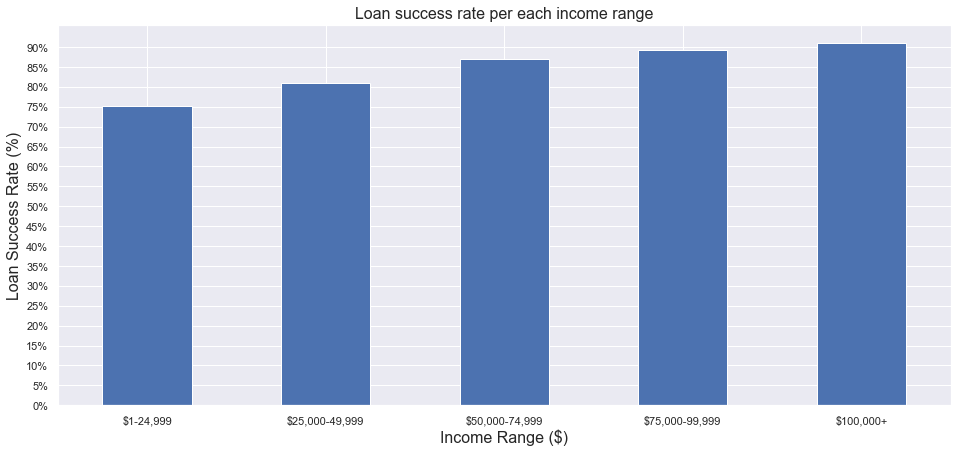

```python
# Considering only Completed and Current lonas as succeeded loans
sb.set(rc={'figure.figsize':(16,7)})
sb.set_style('darkgrid')

tmp1= df2.groupby(['IncomeRange', 'LoanStatus'])['Term'].count().reset_index().query('LoanStatus == "Completed"').loc[:,['IncomeRange','Term']].rename(columns={'Term':'CompletedLoans'})[:-2]
tmp2= df2.groupby(['IncomeRange', 'LoanStatus'])['Term'].count().reset_index().query('LoanStatus == "Current"').loc[:,['IncomeRange','Term']].rename(columns={'Term':'CurrentLoans'})
tmp3= df2.groupby(['IncomeRange'])['Term'].count().reset_index().loc[:,['IncomeRange','Term']].rename(columns={'Term':'TotalLoans'})[:-2]
tmp= pd.merge(tmp1, tmp2, on= 'IncomeRange', how= 'inner').merge(tmp3, on= 'IncomeRange', how= 'inner').set_index('IncomeRange')
tmp['SuccessRate']= ( tmp['CompletedLoans'] + tmp['CurrentLoans'] )/ tmp['TotalLoans']*100


ax= tmp['SuccessRate'].sort_values(ascending=True).plot(kind='bar', width=.5, rot=0)

plt.title('Loan success rate per each income range', fontsize=16)
plt.xlabel('Income Range ($)', fontsize=16)
plt.ylabel('Loan Success Rate (%)', fontsize=16)
plt.yticks(ticks=np.arange(0,95,5))
ax.yaxis.set_major_formatter(mplt.ticker.PercentFormatter());
```

> As the income range goes high, the ratio of `Completed` and `Current` against each range total loans gets higher as well.

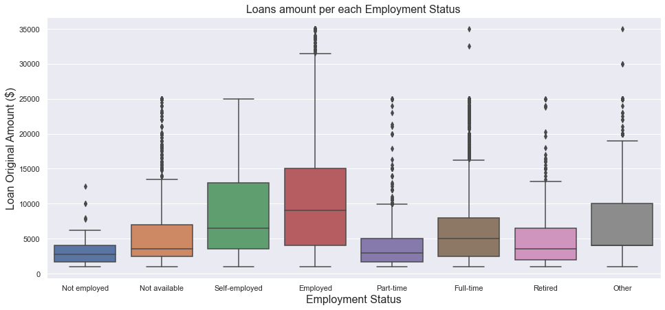

```python
#
sb.set(rc={'figure.figsize':(16,7)})
sb.set_style('darkgrid')

box_order= ['Not employed', 'Not available','Self-employed', 'Employed', 'Part-time','Full-time', 'Retired', 'Other']
ax= sb.boxplot(x='EmploymentStatus', y='LoanOriginalAmount', data= df2, order= box_order)

plt.title('Loans amount per each Employment Status', fontsize=16)
plt.xlabel('Employment Status', fontsize=16)
plt.ylabel('Loan Original Amount ($)', fontsize=16);
```

> Employment status `Not-Employed` and `Part-Time` have the lowest loan amount, common sense as no evidence to convince investors of their repaying ability.

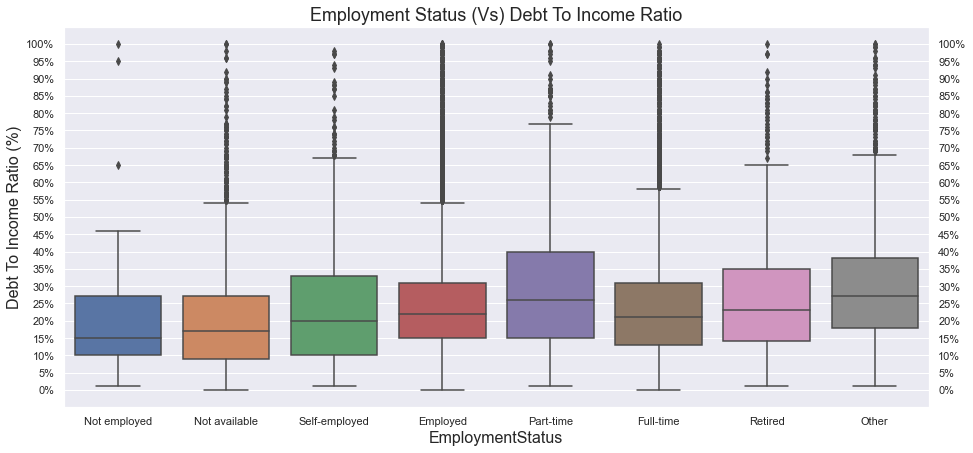

```python
#
sb.set(rc={'figure.figsize':(15.5,7)})
sb.set_style('darkgrid')

box_order= ['Not employed', 'Not available','Self-employed', 'Employed', 'Part-time','Full-time', 'Retired', 'Other']
ax= sb.boxplot(x='EmploymentStatus', y='DebtToIncomeRatio', data= df2, order= box_order)

plt.title('Employment Status (Vs) Debt To Income Ratio', fontsize=18)
plt.xlabel('EmploymentStatus', fontsize=16)
plt.ylabel('Debt To Income Ratio (%)', fontsize=16)
plt.yticks(ticks=np.arange(0,105,5))
ax.tick_params(labelright=True)
ax.yaxis.set_major_formatter(mplt.ticker.PercentFormatter());
```

> No big difference between them all. However, `Full Time` and `Employed` are less than `Self Employed`, `Part Time`, and `Retired` with long dispersed tail for them all.

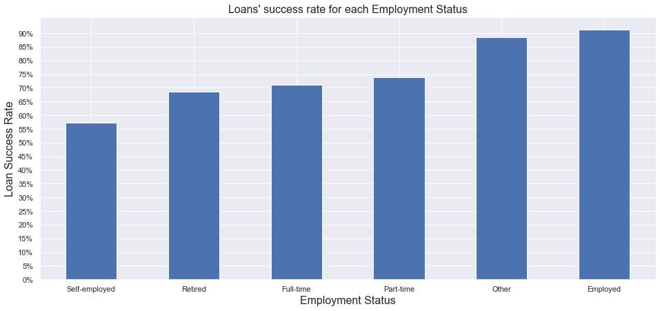

```python
# Considering only Completed and Current lonas as succeeded loans
sb.set(rc={'figure.figsize':(16,7)})
sb.set_style('darkgrid')

tmp1= df2.groupby(['EmploymentStatus', 'LoanStatus'])['Term'].count().reset_index().query('LoanStatus == "Completed"').loc[:,['EmploymentStatus','Term']].rename(columns={'Term':'CompletedLoans'})
tmp2= df2.groupby(['EmploymentStatus', 'LoanStatus'])['Term'].count().reset_index().query('LoanStatus == "Current"').loc[:,['EmploymentStatus','Term']].rename(columns={'Term':'CurrentLoans'})
tmp3= df2.groupby(['EmploymentStatus'])['Term'].count().reset_index().loc[:,['EmploymentStatus','Term']].rename(columns={'Term':'TotalLoans'})
tmp= pd.merge(tmp1, tmp2, on= 'EmploymentStatus', how= 'inner').merge(tmp3, on= 'EmploymentStatus', how= 'inner').set_index('EmploymentStatus')
tmp['SuccessRate']= ( tmp['CompletedLoans'] + tmp['CurrentLoans'] )/ tmp['TotalLoans']*100


ax= tmp['SuccessRate'].sort_values(ascending=True).plot(kind='bar', width=.5, rot=0)

plt.title('Loans\' success rate for each Employment Status', fontsize=16)
plt.xlabel('Employment Status', fontsize=16)
plt.ylabel('Loan Success Rate', fontsize=16)
plt.yticks(ticks=np.arange(0,95,5))
ax.yaxis.set_major_formatter(mplt.ticker.PercentFormatter());
```

> `Employed` and `Other` borrowers showing the highest ratio of `Completed` and `Current` loans against their total loans count, though these two words are ambiguous and not describe this employment status clearly. However, `Part-time` borrowers performing slightly better than `Full-time` borrowers.